# SOM Brero on FS1

# Clustering

- AIC, BIC check were performed on the above SOM brero model.
- Detailed analysis is noted in Best_K_evaluation.rmd
- Two different method used for this analysis.
- Min AIC and BIC was found at k <-c(3,4,8,9)
- Sillhouette and Dunn index were checked for above four K sizes.
- Average silhouette for all four K values was 0.19,0.18,0.2 and 0.2
- Dunn Index was in 0.12,0.12,0.16 and 0.16. Slight difference was after third decimals
- Cluster K =9 has the largest Dunn index= 0.1665
- AIC selects more complex models in comparision with BIC. Such complex models have better predictive accuracy. [Reference :Machine Learning A Probabilistic Perspective ]

```r
FS1_T0_Brero.super1 <- superClass( FS1_T0_Brero , k=3)
```

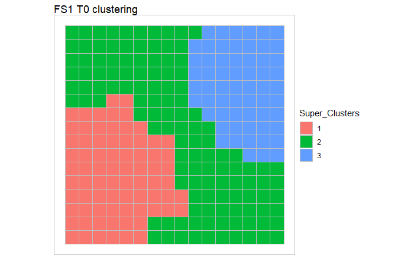

```r
# Neuron number is on each grid. Color indicates the clusters to which it belongs
p1_T0_cluster<-plot(FS1_T0_Brero.super1, type="grid", plot.legend=TRUE, show.names = FALSE)
p1_T0_cluster<- p1_T0_cluster + labs(title = "FS1 T0 clustering")

p1_T0_cluster
```

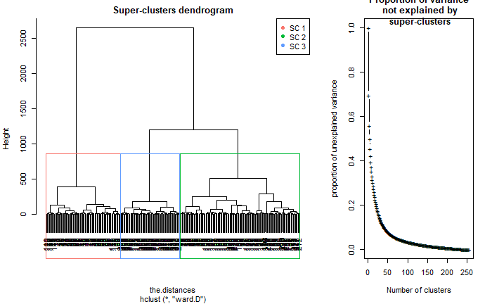

```r
plot ( FS1_T0_Brero.super1, what = "prototypes", show.names = FALSE  )
```

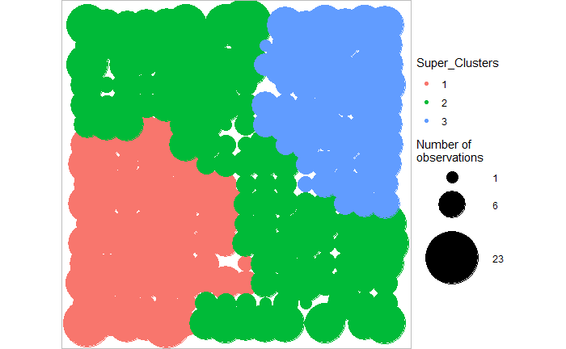

```r
plot ( FS1_T0_Brero.super1, what = "obs", type = "hitmap", show.names = FALSE )
```

```r
summary(FS1_T0_Brero.super1)
```

[output not shown]

|  | F | pvalue | significativity |
| --- | --- | --- | --- |
| .age | 4.758400e+01 | 0.00000000 | *** |
| tq_em | 2.135430e+02 | 0.00000000 | *** |
| tq_co | 1.400480e+02 | 0.00000000 | *** |
| tq_pb | 2.070400e+02 | 0.00000000 | *** |
| tq_inti | 1.357230e+02 | 0.00000000 | *** |
| tq_aku | 6.891500e+01 | 0.00000000 | *** |
| tq_sl | 6.449900e+01 | 0.00000000 | *** |
| tq_som | 8.475600e+01 | 0.00000000 | *** |
| tq_tf | 2.787670e+02 | 0.00000000 | *** |
| sozk_soz01_male | 1.084100e+01 | 0.00000000 | *** |

[output cut: 34 more lines]

```
NA
```

# Temporal aspect

- Three different ways identified to analyze temporal aspect.

```r
#--------------------------------------------------------#
#                   FS1 T1 Data                          #
#--------------------------------------------------------#

#scaled_data_FS1_T1 <- scale(FS1_data_T1)

#--------------------------------------------------------#
#                   FS1 T1 Data                          #
#   Normalized using T0 mu and sigma               #
#--------------------------------------------------------#

scaled_data_FS1_T1 <- read.csv("D:\\DKE\\Thesis_related\\Data\\scaled_data_FS1_T1.csv")
```

```r
#--------------------------------------------------------#
#             Hyper parameter for T1                    #
#  after T1 normalization from T0 perspective           #
#--------------------------------------------------------#
h_dimension_FS1_T1_T <- c(16)# 6
h_radius.type_FS1_T1_T <- c("letremy")
h_dist.type_FS1_T1_T <- c("letremy")
h_init.proto_FS1_T1_T <- c("random")
h_scaling_FS1_T1_T <- c("center")
h_eps_0_FS1_T1_T <- c(0.8944444)
h_maxit_FS1_T1_T <-c(89556)
```

```r
#--------------------------------------------------------#
#             Hyper parameter for T1                    #
#  after T1 normalization from T0 perspective           #
#--------------------------------------------------------#
h_dimension_FS1_T1_T <- c(16)# 6
h_radius.type_FS1_T1_T <- c("letremy")
h_dist.type_FS1_T1_T <- c("letremy")
h_init.proto_FS1_T1_T <- c("random")
h_scaling_FS1_T1_T <- c("center")
h_eps_0_FS1_T1_T <- c(0.8944444)
h_maxit_FS1_T1_T <-c(89556)
```

*Method 1* Training on FS1_T1 using T0 code vector * Using proto0 hyper parameter.

```r
quality(FS1_T1_Brero_usingT0, quality.type="all")
```

```
$topographic
[1] 0.1640849

$quantization
[1] 17.62884
```

```r
# $topographic [1] 0.2725186 $quantization [1] 16.49615
```

```r
#-----Get the count of instances per unit or neuron : Start--------#
df_clu_T1_usingT0 <-as.data.frame(FS1_T1_Brero_usingT0$clustering)# this has which sample is mapped to which neurons
df_clu_T1_usingT0 <- df_clu_T1_usingT0 %>% mutate(id = row_number())
names(df_clu_T1_usingT0)
```

```
[1] "FS1_T1_Brero_usingT0$clustering" "id"
```

```r
df_clu_T1_usingT0 <- df_clu_T1_usingT0 %>%
  rename(
     "Neuron_Number"="FS1_T1_Brero_usingT0$clustering"
  )


#df_clu1 <- dplyr::group_by(df_clu, Neuron_Number)
df_clu1_T1_usingT0 <- df_clu_T1_usingT0 %>% group_by(Neuron_Number) %>% summarise(count_instances = n())


head(df_clu1_T1_usingT0)
```

| Neuron_Number | count_instances |
| --- | --- |
| 1 | 12 |
| 3 | 9 |
| 4 | 4 |
| 5 | 10 |
| 6 | 7 |
| 7 | 3 |

```r
#nrow(df_clu)
#all(df_clu$Neuron_Number == 0)
#sum(df_clu1$count_instances)

Empty_T1_usingT0=( h_dimension_T*h_dimension_T)-nrow(df_clu1_T1_usingT0)

print(paste0("SOM dimention ",h_dimension_T,"X",h_dimension_T," has ",Empty_T1_usingT0," empty neurons"))
```

```
[1] "SOM dimention 16X16 has 11 empty neurons"
```

```r
#-----Get the count of instances per unit or neuron : End--------#
```

```r
#-----Get the count of instances per unit or neuron : Start--------#
df_clu_T1_usingT0 <-as.data.frame(FS1_T1_Brero_usingT0$clustering)# this has which sample is mapped to which neurons
df_clu_T1_usingT0 <- df_clu_T1_usingT0 %>% mutate(id = row_number())
names(df_clu_T1_usingT0)
df_clu_T1_usingT0 <- df_clu_T1_usingT0 %>%
  rename(
     "Neuron_Number"="FS1_T1_Brero_usingT0$clustering"
  )


#df_clu1 <- dplyr::group_by(df_clu, Neuron_Number)
df_clu1_T1_usingT0 <- df_clu_T1_usingT0 %>% group_by(Neuron_Number) %>% summarise(count_instances = n())


head(df_clu1_T1_usingT0)
#nrow(df_clu)
#all(df_clu$Neuron_Number == 0)
#sum(df_clu1$count_instances)

Empty_T1_usingT0=( h_dimension_T*h_dimension_T)-nrow(df_clu1_T1_usingT0)

print(paste0("SOM dimention ",h_dimension_T,"X",h_dimension_T," has ",Empty_T1_usingT0," empty neurons"))

#-----Get the count of instances per unit or neuron : End--------#
```

[output not shown]